# Homework #3

**See Canvas for the due date**. Complete all of the following problems. Ideally, the theoretical problems should be answered in a Markdown cell directly underneath the question. If you don't know LaTex/Markdown, you may submit separate handwritten solutions to the theoretical problems. Please do not turn in messy work. Computational problems should be completed in this notebook (using the R kernel is preferred). Computational questions may require code, plots, analysis, interpretation, etc. Working in small groups is allowed, but it is important that you make an effort to master the material and hand in your own work.

## A. Theoretical Problems

### A.1 Deriving the t-statistic

In this question, we'll walk through the proof that the t-test statistic has a t-distribution. More specifically, consider the simple linear regression model $Y_i = \beta_0 + \beta_1x_i + \varepsilon_i$, where $\varepsilon_i \overset{iid}{\sim} N(0,\sigma^2)$, $x_i$ are fixed and known, $\sigma^2$, $\beta_0$ and $\beta_1$ are fixed and unknown, and $i=1,...,n$. We estimate $\beta_0$ and $\beta_1$ using least squares, and denote the least squares estimators $\widehat\beta_0$ and $\widehat\beta_1$.

Consider testing the hypotheses $H_0: \beta_1 = 0 \,\,\, vs \,\,\, H_1: \beta_1 \ne 0$. In class, we claimed that the appropriate test statistics is

\begin{align*} t = \frac{\widehat\beta_1}{\widehat{s.e.}(\widehat\beta_1)}, \end{align*}

where, for simple linear regression, $$\widehat{s.e.}(\widehat\beta_1) = \sqrt{\frac{\widehat{\sigma}^2}{\sum^n_{i=1}\left(x_i - \bar{x}\right)^2}} \,\,\,\, , \text{ and } \,\,\,\,\, \,\, \widehat{\sigma}^2 = \frac{RSS}{(n - 2)}.$$

Further, we claimed that $t \sim t\left(n - 2 \right)$. That is, the test statistic $t$ has a t-distribution with $n-2$ degrees of freedom. Let's prove it in a few steps!

**A.1 (a) [5 points] Recall that $\displaystyle\widehat\beta_1 \sim N\left(\beta_1, \,\, \frac{\sigma^2}{\sum^n_{i=1}\left(x_i - \bar{x}\right)^2} \right)$. Argue that $\displaystyle Z = \frac{\widehat\beta_1}{\sqrt{\frac{\sigma^2}{\sum^n_{i=1}\left(x_i - \bar{x}\right)^2}}}$ has a standard normal distribution under $H_0$. (This should be easy!)**

Well first, we know to have a standard normal distribution means: $$ Z = \frac{x - \mu}{\sigma} \sim N(0,1) $$

And since we are considering the test case $H_0: \beta_1 = 0$ and $\hat\beta_1$ is normally distributed we have our test statistic to be: $$ Z = \frac{\hat\beta_1 - c}{\sigma} \sim N(0,1) $$

Where $c = H_0$, we have, $$ Z = \frac{\hat\beta_1 - \beta_1}{\sqrt{\frac{\sigma^2}{\sum^n_{i=1}\left(x_i - \bar{x}\right)^2}}} = \frac{\hat\beta_1}{\sqrt{\frac{\sigma^2}{\sum^n_{i=1}\left(x_i - \bar{x}\right)^2}}} $$

**A.1 (b) Now let's show that $\displaystyle W = \frac{\left(n - 2\right)\widehat\sigma^2}{\sigma^2}$ follows a $\chi^2$ distribution with $n-2$ degrees of freedom.**

For shorthand, let $\mu_{y_i|x_i} = \beta_0 + \beta_1x_i$.

**A.1 (b) (i). [5 points] First, show that $\displaystyle \frac{\sum^n_{i=1}\left(y_i - \mu_{y_i|x_i}\right)^2}{\sigma^2} \sim \chi^2(n)$. This should follow straight from the definition of the $\chi^2(n)$ distribution given in class, along with some easy algebra!**

From the definition of a Chi-Square Distribution, we know that if, $$ X \sim N(\mu, \sigma^2) \\ \text{then} \\ (\frac{x-\mu}{\sigma})^2 \sim \chi^2(1) $$ Therefore if, $$ X_1, ..., X_n \overset{\text{iid}}\sim N(\mu, \sigma^2) \\ \text{then} \\ \sum^n_{i=1}(\frac{x_i - \mu}{\sigma})^2 \sim \chi^2(n) $$ We have that $\mu$ and $\sigma$ are constants and from our previous assigment we showed that $y_i \sim N(X\beta, \sigma^2I_n)$, ergo, $$ \frac{\sum^n_{i=1}\left(y_i - \mu_{y_i|x_i}\right)^2}{\sigma^2} \sim \chi^2(n) \displaystyle \equiv \sum^n_{i=1}\big(\frac{y_i - \mu_{y_i|x_i}}{\sigma}\big)^2 \sim \chi^2(n) $$

**A.1 (b) (ii). [10 points] Now, show that $\displaystyle \frac{\sum^n_{i=1}\left(y_i - \mu_{y_i|x_i}\right)^2}{\sigma^2} = \frac{\sum^n_{i=1}\left(y_i - \widehat{y}_i\right)^2}{\sigma^2} + \frac{\sum^n_{i=1}\left(\widehat{y}_i - \mu_{y_i|x_i}\right)^2}{\sigma^2}$. (HINT: add and subtract $\widehat{y}_i$ to the lefthand side.)**

Note that the middle term $\frac{\sum^n_{i=1}\left(y_i - \widehat{y}_i\right)^2}{\sigma^2}$ can be written as $\frac{RSS}{\sigma^2}$, or equivalently, $\frac{(n-2)\widehat\sigma^2}{\sigma^2}.$

$$ \frac{\sum^n_{i=1}\left(y_i - \mu_{y_i|x_i}\right)^2}{\sigma^2} = \frac{1}{\sigma^2}\sum^n_{i=1}(y_i - \hat{y}_i + \hat{y_i} - \mu_{y_i|x_i})^2 \\ \Rightarrow \frac{1}{\sigma^2}\sum^n_{i=1}(y_i - \hat{y_i})^2 + 2(y_i - \hat{y}_i)(\hat{y}_i - \mu_{y_i|x_i}) + (\hat{y}_i - \mu_{y_i|x_i})^2 \\ \Rightarrow\frac{1}{\sigma^2}\bigg(\sum^n_{i=1}(y_i- \hat{y}_i)^2 + 2\sum^n_{i=1}(y_i- \hat{y}_i)(\hat{y}_i - \mu_{y_i|x_i}) + \sum^n_{i=1}(\hat{y}_i - \mu_{y_i|x_i})^2\bigg) $$

Previously, in HW $2$, we showed the $\sum^n_{i=1}\hat\epsilon_i = \sum^n_{i=1}(y_i - \hat{y}_i) = 0$ therefore: $$ \frac{1}{\sigma^2}\bigg(\sum^n_{i=1}(y_i- \hat{y}_i)^2 + 2\sum^n_{i=1}\cdot 0\cdot (\hat{y}_i - \mu_{y_i|x_i}) + \sum^n_{i=1}(\hat{y}_i - \mu_{y_i|x_i})^2\bigg) \\ \Rightarrow\frac{1}{\sigma^2}\bigg(\sum^n_{i=1}(y_i- \hat{y}_i)^2 + 0 + \sum^n_{i=1}(\hat{y}_i - \mu_{y_i|x_i})^2\bigg) \\ \Rightarrow\frac{\sum^n_{i=1}\left(y_i - \widehat{y}_i\right)^2}{\sigma^2} + \frac{\sum^n_{i=1}\left(\widehat{y}_i - \mu_{y_i|x_i}\right)^2}{\sigma^2} $$

Ok, so maybe we won't do the *entire* proof. Note, without having to prove it, that $\displaystyle\frac{(n-2)\widehat\sigma^2}{\sigma^2} \sim \chi^2(n-2)$. This is because

$$\displaystyle \underbrace{\frac{\sum^n_{i=1}\left(y_i - \mu_{y|x}\right)^2}{\sigma^2}}_{\chi^2(n)} = \underbrace{\frac{(n-2)\widehat\sigma^2}{\sigma^2}}_{\chi^2(n - 2)} + \underbrace{\frac{\sum^n_{i=1}\left(\widehat{y}_i - \mu_{y|x}\right)^2}{\sigma^2}}_{\chi^2(2)},$$

which follows from some facts about the $\chi^2$ distribution involving moment generating functions. Math Stat students, you should know how to prove this :)

With $\displaystyle\frac{(n-2)\widehat\sigma^2}{\sigma^2} \sim \chi^2(n-2)$ in hand, let's finish the proof that our test statistic for individual t-tests follows a t distribution with $n-2$ degrees of freedom.

By definition, a random variable $T$ has a t-distribution with $d$ degrees of freedom if it can be written as

$$T = \frac{Z}{\sqrt{W\big/d}},$$

where $Z \sim N(0,1)$ and $W \sim \chi^2(d)$.

**A.1 (c) [10 points] Prove that $t = \frac{\widehat\beta_1}{\widehat{s.e.}(\widehat\beta_1)}$ can be written in the form of a t-distributed random variable with $n-2$ degrees of freedom. Specifically, let $Z$ be defined as in problem A.1 (a), and $W = \frac{(n-2)\widehat\sigma^2}{\sigma^2}$. Show that**

\begin{align*} \frac{Z}{\sqrt{W\big/(n-2)}} = \frac{\widehat\beta_1}{\widehat{s.e.}(\widehat\beta_1)} = t , \end{align*}

which, by definition, means that $t \sim t(n-2)$.

$$ \frac{Z}{\sqrt{\frac{w}{n-2}}} = \frac{Z}{\sqrt{\frac{\frac{(n-2)\hat\sigma^2}{\sigma^2}}{n-2}}} \\ \Rightarrow \frac{Z}{\sqrt{\frac{\hat\sigma^2}{\sigma^2}}} = \frac{\frac{\hat\beta_1}{\sqrt{\frac{\sigma^2}{\sum^n_{i=1}(x_i - \bar{x})^2}}}}{\sqrt{\frac{\hat\sigma^2}{\sigma^2}}} \\ \Rightarrow \frac{\hat\beta_1}{\sqrt{\frac{\sigma^2}{\sum^n_{i=1}(x_i - \bar{x})^2}\frac{\hat\sigma^2}{\sigma^2}}} = \frac{\hat\beta_1}{\sqrt{\frac{\hat\sigma^2}{\sum^n_{i=1}(x_i - \bar{x})^2}}} \\ \Rightarrow \frac{\hat\beta_1}{\hat{s.e}(\hat\beta_1)} = t $$

### Problem A.2 (STAT 5010 Students Only)

*Over the next few classes, we will be discussing the use of regression--and statistical modeling more generally--for prediction and explanation. The purpose of this problem is to encourage you to gain a deeper understanding of prediction, explanation, and the relationship between these two concepts.*

**[10 points] Read “To Explain or to Predict?” by Galit Shmueli and answer at least three of the following questions. Each answer should be typed in a markdown cell in this notebook, and roughly one paragraph (5-10 sentences) in length. The goal of this assignment is to provide the opportunity to think more rigorously about some of the statistical models that we will encounter in this course. What is their purpose? How can we get the most out of our statistical analysis?**

1. What is explanatory modeling? Where is explanatory modeling most often used? What does explanatory modeling have to do with causality?
2. What is predictive modeling? Where is predictive modeling most often used? What does predictive modeling have to do with causality?
3. How are explanation and prediction different? Is it universally recognized that they are different?
4. Describe how, according to Shmueli, the statistical modeling procedure might change based on whether the goal of the modeling is explanation or prediction.
5. What are some suggestions that Shmueli gives to the statistical community based on his analysis of prediction and explanation? Do you agree with these suggestions?

(If you did this as your "classwork #0" assignment, then, lucky you! Review and past your answers here.)

$1.$ From the words of Shmueli explanatory and predictive modeling reflect on the process of using data and statistical methods for explaining and predicting. Explaining is defined as a causal relationship and so we define explanatory as the use of statistical models for testing causal explanations. Explanatory modeling is most often used in social sciences where they are used to exclusively test causal theory. Explanatory modeling has to do with causality because explanatory modeling refers to the application of statistical models to data for testing causal hypothesis about theoretical constructs.

$2.$ First, predictions include point or interval predictions, prediction regions, predictive distribution, or ranking of new observations. Predictive modeling is defined as the process of applying a statistical model or data mining algorithm to data for the purpose of predicting new or future observations. So any method that produces predictions regardless of its underlying approach is a predictive model. Predictive modeling is commonly absent in many scientific fields as a tool for developing theory, however, its more frequently used for theory building and testing. Predicitive modeling corresponds with causality because predictive modeling can help uncover potential new causal mechanisms and lead to the generation of new hypothesis. In addition, predictive modelin can help discover new measures as well as to compare different operationalizations of constructs and different measurement instruments.

$3.$ Explanation and prediction are different because explanations is aimed at comprehending and justifying while prediction looks for inferences and connections. As stated in the article explanation and prediction are like "basic science" and "applied science," respectively. Basic science is directed at knowing and understanding, on the other hand, applied science allows inferences and predictions to be made from known values of some of the variables to unknown values of other varaibles. No, it is not universally recongnized that they are different. Sometimes they are conflated sometimes confused. The reason why there should be a difference is because measurable data are not accurate repesentations of their underlying constructs. The operationilization of theories and constructs create internal disparities between explaining and predicting.

## B. Computational Problems

```r
library(testthat)
```

```
Error in library(testthat): there is no package called ‘testthat’
Traceback:

1. library(testthat)
```

## Problem B.1: Comparing Models (20 points)

In this exercise, we will fit multiple different models to the same data and determine which of those models we should ultimately use.

The data we will be using is the Auto MPG Data Set from the UCI Machine Learning Repository. It contains technical specifications and performance ratings of many different cars. We will focus on the features that impact the overall `mpg` of each car.

In the cell below, code is provided for you to load in the data and rename the columns to be more specific.

```r
library(ggplot2)


mpg.data = na.omit(read.csv(url(paste0("https://raw.githubusercontent.com/bzaharatos/",
                               "-Statistical-Modeling-for-Data-Science-Applications/",
                               "master/Modern%20Regression%20Analysis%20/Datasets/auto-mpg.csv"))))


names(mpg.data) = c("mpg", "cylinders", "displacement", "horsepower", "weight",
                    "accel", "model_year", "origin", "car_name")
mpg.data$horsepower = as.numeric(mpg.data$horsepower)
summary(mpg.data)
```

```
      mpg          cylinders      displacement     horsepower        weight
 Min.   : 9.00   Min.   :3.000   Min.   : 68.0   Min.   : 46.0   Min.   :1613
 1st Qu.:17.00   1st Qu.:4.000   1st Qu.:105.0   1st Qu.: 75.0   1st Qu.:2225
 Median :22.75   Median :4.000   Median :151.0   Median : 93.5   Median :2804
 Mean   :23.45   Mean   :5.472   Mean   :194.4   Mean   :104.5   Mean   :2978
 3rd Qu.:29.00   3rd Qu.:8.000   3rd Qu.:275.8   3rd Qu.:126.0   3rd Qu.:3615
 Max.   :46.60   Max.   :8.000   Max.   :455.0   Max.   :230.0   Max.   :5140

     accel         model_year        origin                    car_name
 Min.   : 8.00   Min.   :70.00   Min.   :1.000   amc matador       :  5
 1st Qu.:13.78   1st Qu.:73.00   1st Qu.:1.000   ford pinto        :  5
 Median :15.50   Median :76.00   Median :1.000   toyota corolla    :  5
 Mean   :15.54   Mean   :75.98   Mean   :1.577   amc gremlin       :  4
 3rd Qu.:17.02   3rd Qu.:79.00   3rd Qu.:2.000   amc hornet        :  4
 Max.   :24.80   Max.   :82.00   Max.   :3.000   chevrolet chevette:  4
                                                 (Other)           :365
```

#### B.1 (a) [6 points] Three Different Models

We will fit three different models to this data:

1. `mod.1`: Fits `mpg` as the response with `weight` as the predictor.
2. `mod.2`: Fits `mpg` as the response with `weight` and `accel` as predictors.
3. `mod.3`: Fits `mpg` as the response with `weight`, `accel` and `horsepower` as predictors.

Fit these models in the cell below.

```r
mod.1 = lm(mpg ~ weight, data = mpg.data)
mod.2 = lm(mpg ~ weight + accel, mpg.data)
mod.3 = lm(mpg ~ weight + accel + horsepower, mpg.data)
```

```r
# Test Cell
# Make sure that each model is a linear model
if(test_that("Testing model types",
             {(expect_is(mod.1, "lm"))
              (expect_is(mod.2, "lm"))
              (expect_is(mod.3, "lm"))})){
    print("All models are linear models.")
}else{
    print("At least one of the models isn't a linear model!")
    print("Make sure you're using the lm() function.")
}
```

```
Error in test_that("Testing model types", {: could not find function "test_that"
Traceback:
```

**B.1 (b) [9 points] Partial F-Tests**

Compare the 3 models using pairwise F-tests to determine which of the three we should use moving forward. It may be helpful to write out the null and alternative hypotheses for these tests.

Copy your selected model into the `final.model` variable.

$h_0: $ is the reduced model therefore `mod.1`. $h_1: $ is the full model. In our case this will be the model that has that continues to be significant `mod.2` or `mod.3`.

```r
anova(mod.1, mod.2)
anova(mod.2,mod.3)
final.model = mod.3
```

| Res.Df | RSS | Df | Sum of Sq | F | Pr(>F) |
| --- | --- | --- | --- | --- | --- |
| 390 | 7321.234 | NA | NA | NA | NA |
| 389 | 7152.893 | 1 | 168.3407 | 9.15497 | 0.002645259 |

| Res.Df | RSS | Df | Sum of Sq | F | Pr(>F) |
| --- | --- | --- | --- | --- | --- |
| 389 | 7152.893 | NA | NA | NA | NA |
| 388 | 6993.840 | 1 | 159.0527 | 8.823826 | 0.003158152 |

```r
# Test Cell
if(test_that("Check final.model class", {expect_is(final.model, "lm")})){
    print("You've selected a model! Make sure you're confident in your answer.")
}else{
    print("final.model is not a linear model.")
    print("To copy the selected model use `final.model = mod.#`")
}
```

**B.1 (c) [6 points] Coefficient Confidence Intervals**

Using your selected best model, calculate a $95\%$ confidence interval for the `weight` parameter (you can use the `confint()` function). Save the lower and upper values into `weight.CI.lower` and `weight.CI.upper` respectively.

```r
ci = confint(mod.3, level=0.95)
weight.CI.lower = ci[2,1]
weight.CI.upper = ci[2,2]
weight.CI.lower
weight.CI.upper
```

-0.00692495337777273

-0.00465385180674534

```r
# Test Cell
```

**B.1 (d) [9 points] Model Comparison**

So far, we've used the F-test as a way to choose a "best" model among the three proposed. Now let's compare the models according to their mean squared errors (MSE). The MSE is defined as

\begin{align*} MSE = \frac{1}{n}\sum^n_{i=1}\left(y_i - \widehat{y}_i \right)^2. \end{align*}

Compute the MSE for each of the three models and save their values into their respective `MSE.#` variables.

Which of these models has the best MSE? Do these conclusions agree with the model you selected in part **1.b**? Think about why or why not.

```r
MSE.1 = mean(residuals(mod.1)^2)
MSE.2 = mean(residuals(mod.2)^2)
MSE.3 = mean(residuals(mod.3)^2)
MSE.1
MSE.2
MSE.3
```

18.6766165974193

18.2471761042759

17.841429544544

```r
# Test Cell
```

The model with the best MSE is `mod.3`. This conclusion does agree with the model that I selected in part **1.b**. I think we have a better MSE for `mod.3` because of the increase in parameters. As said about $R^2$, we should not compare models with a different number of predictiors because in can cause a huge increases in calculating our MSE. I think that the increase in predictors caused the decrease in `mod.3`'s MSE. Since MSE relies on calculating the RSS it can be said that the more predictors that larger the smaller the RSS. Therefore `mod.3` has a smaller MSE.

### Problem B.2

In this problem, we'll use a [dataset](https://dasl.datadescription.com/datafile/amazon-books/?_sfm_methods=Multiple+Regression&_sfm_cases=4+59943) about book prices from Amazon. The data consists of data on $n = 325$ books and includes measurements of:

- `aprice`: The price listed on Amazon (dollars)
- `lprice`: The book's list price (dollars)
- `weight`: The book's weight (ounces)
- `pages`: The number of pages in the book
- `height`: The book's height (inches)
- `width`: The book's width (inches)
- `thick`: The thickness of the book (inches)
- `cover`: Whether the book is a hard cover of paperback.
- And other variables...

We'll explore a model that will use `lprice`, `pages`, and `width` to predict `aprice`. Here, I use the same cleaning method described in an example in lecture.

**B.2 (a) [2 points] Load the dataset and explore it graphically and numerically. Are there relationships between variables?**

```r
library(ggplot2)

amazon = read.csv(url("https://raw.githubusercontent.com/bzaharatos/STAT-5630/main/amazon.txt"), sep = "\t")
names(amazon)
df = data.frame(aprice = amazon$Amazon.Price, lprice = as.numeric(amazon$List.Price),
                pages = amazon$NumPages, width = amazon$Width, weight = amazon$Weight..oz,
                height = amazon$Height, thick = amazon$Thick, cover = amazon$Hard..Paper)

summary(df)

#imputing
df$lprice[which(is.na(df$lprice))] = mean(df$lprice, na.rm = TRUE)
df$weight[which(is.na(df$weight))] = mean(df$weight, na.rm = TRUE)
df$pages[which(is.na(df$pages))] = mean(df$pages, na.rm = TRUE)
df$height[which(is.na(df$height))] = mean(df$height, na.rm = TRUE)
df$width[which(is.na(df$width))] = mean(df$width, na.rm = TRUE)
df$thick[which(is.na(df$thick))] = mean(df$thick, na.rm = TRUE)
df = df[-205,]
summary(df)
```

1. 'Title'

2. 'Author'

3. 'List.Price'

4. 'Amazon.Price'

5. 'Hard..Paper'

6. 'NumPages'

7. 'Publisher'

8. 'Pub.year'

9. 'ISBN.10'

10. 'Height'

11. 'Width'

12. 'Thick'

13. 'Weight..oz.'

```
     aprice           lprice           pages           width
 Min.   :  0.77   Min.   :  1.50   Min.   : 24.0   Min.   :4.100
 1st Qu.:  8.60   1st Qu.: 13.95   1st Qu.:208.0   1st Qu.:5.200
 Median : 10.20   Median : 15.00   Median :320.0   Median :5.400
 Mean   : 13.33   Mean   : 18.58   Mean   :335.9   Mean   :5.585
 3rd Qu.: 13.13   3rd Qu.: 19.95   3rd Qu.:416.0   3rd Qu.:5.900
 Max.   :139.95   Max.   :139.95   Max.   :896.0   Max.   :9.500
                  NA's   :1        NA's   :2       NA's   :5
     weight          height           thick        cover
 Min.   : 1.20   Min.   : 5.100   Min.   :0.1000   H: 89
 1st Qu.: 7.80   1st Qu.: 7.900   1st Qu.:0.6000   P:236
 Median :11.20   Median : 8.100   Median :0.9000
 Mean   :12.49   Mean   : 8.163   Mean   :0.9077
 3rd Qu.:16.00   3rd Qu.: 8.500   3rd Qu.:1.1000
 Max.   :35.20   Max.   :12.100   Max.   :2.1000
 NA's   :9       NA's   :4        NA's   :1
```

```
     aprice            lprice           pages           width
 Min.   :  0.770   Min.   :  1.50   Min.   : 24.0   Min.   :4.100
 1st Qu.:  8.598   1st Qu.: 13.95   1st Qu.:208.0   1st Qu.:5.200
 Median : 10.200   Median : 15.00   Median :320.0   Median :5.400
 Mean   : 13.010   Mean   : 18.58   Mean   :335.8   Mean   :5.584
 3rd Qu.: 13.033   3rd Qu.: 19.95   3rd Qu.:416.0   3rd Qu.:5.900
 Max.   :139.950   Max.   :139.95   Max.   :896.0   Max.   :9.500
     weight          height           thick       cover
 Min.   : 1.20   Min.   : 5.100   Min.   :0.100   H: 89
 1st Qu.: 7.80   1st Qu.: 7.900   1st Qu.:0.600   P:235
 Median :11.20   Median : 8.100   Median :0.900
 Mean   :12.48   Mean   : 8.161   Mean   :0.908
 3rd Qu.:16.00   3rd Qu.: 8.500   3rd Qu.:1.100
 Max.   :35.20   Max.   :12.100   Max.   :2.100
```

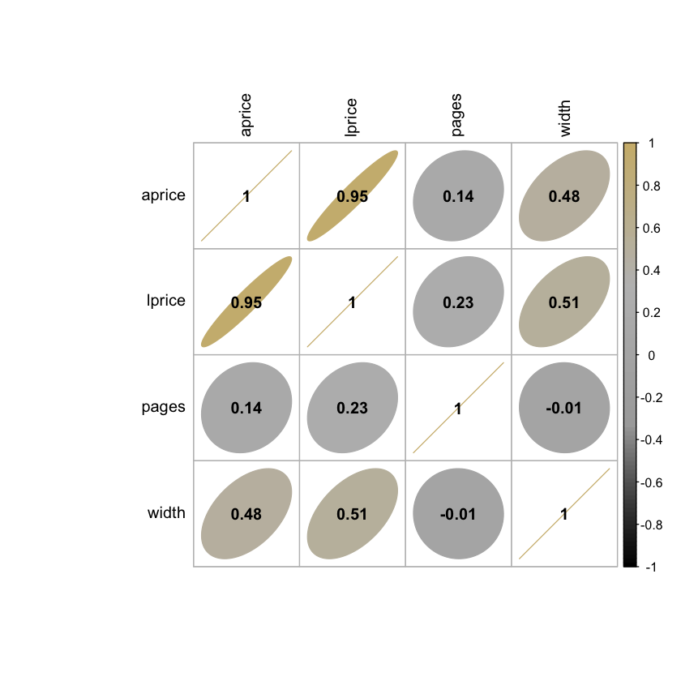

| aprice | lprice | pages | width |
| --- | --- | --- | --- |
| 5.18 | 12.95 | 304 | 5.5 |
| 10.20 | 15.00 | 273 | 5.5 |
| 1.50 | 1.50 | 96 | 5.2 |
| 10.87 | 15.99 | 672 | 6.0 |
| 16.77 | 30.50 | 720 | 5.2 |
| 16.44 | 28.95 | 460 | 6.3 |

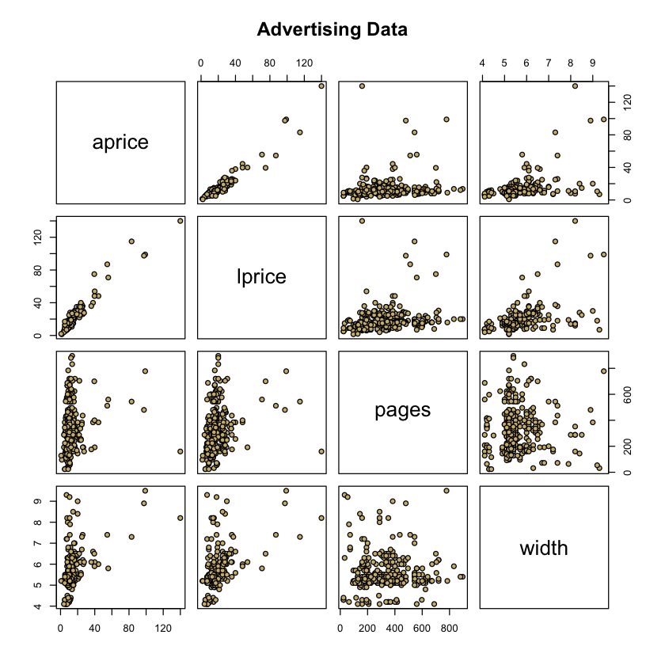

```r
library(corrplot)
library(tidyverse)  # data manipulation and visualization
library(modelr)     # provides easy pipeline modeling functions
library(broom)      # helps to tidy up model outputs

col4 = colorRampPalette(c("black", "darkgrey", "grey", "#CFB87C"))
corrplot(cor(df[,1:4]), method = "ellipse", col = col4(100), addCoef.col = "black", tl.col = "black")
plot(df[,1:4],main = "Advertising Data",pch = 21, bg = c("#CFB87C"))
head(df[,1:4])
```

Observing **corrplot**, `aprice` and `lprice` have a significant association with each other. The value shown for `aprice` vs `lprice` shows a strong linear relationship. As for the rest of the variables some appear linear and we do have a few outliers. Note that outliers have a significant impact on statistical significance.

**B.2 (b) [3 points] Randomly split the dataset into two parts:**

1. **80% of the data stored in the variable `train`. This will be the data that we fit/train our model on.**
2. **the remaining 20% of the data stored in the variable `test`. We will use this data to test our predictions.**

```r
set.seed(1989) #don't change the seed!

n = floor(0.8 * nrow(df))
indicies = sample(seq_len(nrow(df)), size = n)

train = df[indicies, ]
test = df[-indicies, ]

cat("80%, ", dim(train)[1], 'rows and ', dim(train)[2], "columns in training set\n")
cat("20%, ", dim(test)[1], "rows and",dim(test)[2],"columns in testing set.")
```

```
80%,  259 rows and  8 columns in training set
20%,  65 rows and 8 columns in testing set.
```

**B.2 (c) [3 points] Conduct simple linear regression, using the `lm_amazon = lm()` function and your training set, `train`, with `aprice` as the response, and `lprice` as the predictor.**

```r
lm_amazon = lm(aprice ~ lprice, train)
summary(lm_amazon)
```

```
Call:
lm(formula = aprice ~ lprice, data = train)

Residuals:
    Min      1Q  Median      3Q     Max
-22.287  -1.873  -0.131   2.022  22.251

Coefficients:
            Estimate Std. Error t value Pr(>|t|)
(Intercept) -2.88501    0.40174  -7.181 7.44e-12 ***
lprice       0.86162    0.01708  50.442  < 2e-16 ***
---
Signif. codes:  0 ‘***’ 0.001 ‘**’ 0.01 ‘*’ 0.05 ‘.’ 0.1 ‘ ’ 1

Residual standard error: 3.996 on 257 degrees of freedom
Multiple R-squared:  0.9083,	Adjusted R-squared:  0.9079
F-statistic:  2544 on 1 and 257 DF,  p-value: < 2.2e-16
```

**B.2 (d) [8 points] We learned that, often, the goal of regression is to make predictions on new data. Let's see how well the model does at predicting values that we left out of the training set.**

**We can get a sense of how well the model does at predicting by computing the mean squared prediction error (MSPE):**

\begin{align*} MSPE = \frac{1}{k}\sum^k_{i=1}\left(y^\star_i - \widehat{y}^\star_i \right)^2 = \frac{1}{k}\sum^k_{i=1}\left(y^\star_i - \mathbf{x}^\star_i\boldsymbol{\widehat\beta} \right)^2 \end{align*}

where:

- $k$ is the number of rows in the `test` set.
- $y^\star_i$ is the $i^{th}$ response value in the `test` set.
- $\mathbf{x}_i^\star = \left(1,x_{i,1}^\star, x_{i,2}^\star,...,x_{i,p}^\star \right)$ is the $i^{th}$ set of predictors (and a 1 for the intercept multiplication...) in the `test` set. Notice that it's a row vector.
- $\widehat{\boldsymbol\beta}$ is the least squares estimate of $\boldsymbol\beta$, fit on the *training set*, `train`.

**Compute the MSPE for your `test` data.**

```r
# number of rows in test set
k = dim(test)[1]

# The lprice predictor and 1 for the intercept multiplication
x_star = cbind(1, test$lprice)

# Response value: Amazon price
y_star = test$aprice

#Calculating Beta hat
y = train$aprice
X = cbind(1, train$lprice)
b_hat = solve(t(X)%*%X)%*%t(X)%*%y

# predict(lm_amazon, test)

MSPE = sum((y_star - x_star%*%b_hat)^2)/k
MSPE
```

12.5033364870952

**B.2 (e) [8 points] The mean squared error (MSE) is similar to the MSPE, but it uses the training data instead of the test data. Compute the MSE on your `train` data.**

```r
n = dim(train)[1]
mse = sum(residuals(lm_amazon)^2)/n

mse
```

15.846147718757

### Problem B.3

Now let's perform multiple linear regression using the dataset from Problem B.2

**B.3 (a) [3 points] Perform MLR, using your training set, using `aprice` as the response and all other variables as predictors. Store your `lm()` object in `mlr_amazon`.**

```r
mlr_amazon = lm(aprice ~ lprice + pages + width + weight + height + thick, train)
```

**B.3 (b) [13 points] Compute the MSE for the data in the training set (store in `mse_train`), and for data in the testing set (store in `mse_test`). Which one is lower? Explain why you think it's lower.**

```r
mse_train = mean(residuals(mlr_amazon)^2)


# number of rows in test set
k = dim(test)[1]

# The lprice predictor and 1 for the intercept multiplication
x_star = cbind(1, test[,2], test[,3], test[,4], test[,5], test[,6], test[,7])

# Response value: Amazon price
y_star = test$aprice


#Calculating Beta hat
y = train$aprice
X = cbind(1, train[,2], train[,3], train[,4], train[,5], train[,6], train[,7])
b_hat = solve(t(X)%*%X)%*%t(X)%*%y
mse_test = sum((y_star - x_star%*%b_hat)^2)/k

mse_train
mse_test
```

13.8726830120354

11.9494982447212

`mse_test` is lower. I think it is smaller because we have a smaller dataset and fewer outliers.